# Comparing Trends in R

## Verify assumptions

The easiest way to do this is with diagnostic plots. Simply call `plot` on the model object. By default the 3 most “extreme” measures will be labeled, even if they’re not extreme relative to the rest of the data.

**Check constant variance**. This plot looks perfect. We want a fairly straight red line and even vertical scatter of points.

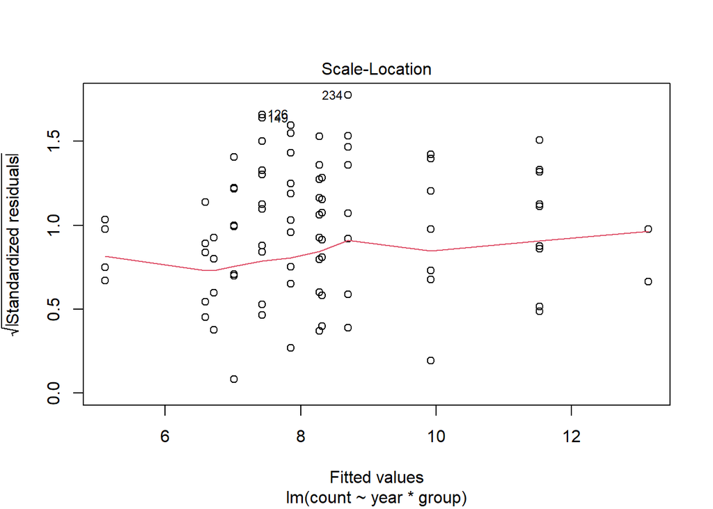

```r
plot(m, which = 3)
```

**Check normality of residuals**. This plot looks perfect. We want the points to fall close to the diagonal line.

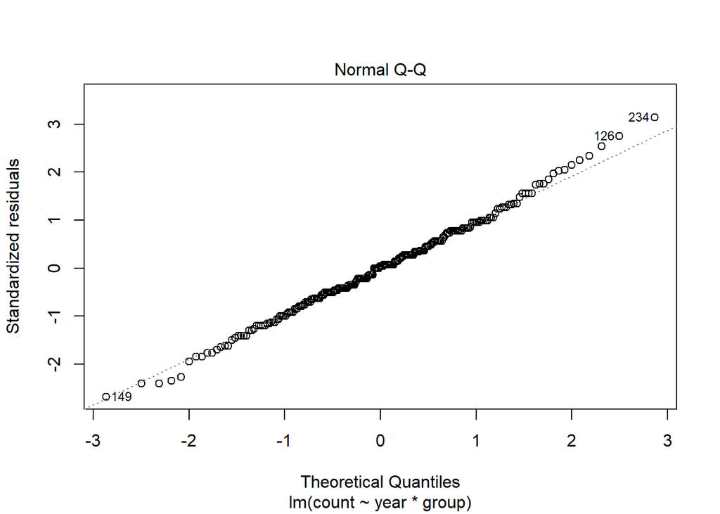

```r
plot(m, which = 2)
```

Both plots look great because I simulated the data according to what ANOVA/ANCOVA models assume.